# Risk Factor Analysis

## Outcome Variable

**Outcome Variable:** pers_wast

## Predictor Variables

**Intervention Variable:** hdlvry

**Adjustment Set:**

- arm
- sex
- W_mage
- meducyrs
- feducyrs
- hhwealth_quart
- hfoodsec
- W_nrooms
- brthmon
- impfloor
- impsan
- safeh20
- delta_W_mage
- delta_meducyrs
- delta_feducyrs
- delta_hhwealth_quart
- delta_hfoodsec
- delta_W_nrooms
- delta_brthmon
- delta_impfloor
- delta_impsan
- delta_safeh20

## Stratifying Variables

The analysis was stratified on these variable(s):

- agecat
- studyid
- country

## Data Summary

| agecat | studyid | country | hdlvry | pers_wast | n_cell | n |
| --- | --- | --- | --- | --- | --- | --- |
| 0-24 months | ki1000108-CMC-V-BCS-2002 | INDIA | 0 | 0 | 339 | 370 |
| 0-24 months | ki1000108-CMC-V-BCS-2002 | INDIA | 0 | 1 | 23 | 370 |
| 0-24 months | ki1000108-CMC-V-BCS-2002 | INDIA | 1 | 0 | 8 | 370 |
| 0-24 months | ki1000108-CMC-V-BCS-2002 | INDIA | 1 | 1 | 0 | 370 |
| 0-24 months | ki1000108-IRC | INDIA | 0 | 0 | 354 | 410 |
| 0-24 months | ki1000108-IRC | INDIA | 0 | 1 | 48 | 410 |
| 0-24 months | ki1000108-IRC | INDIA | 1 | 0 | 8 | 410 |
| 0-24 months | ki1000108-IRC | INDIA | 1 | 1 | 0 | 410 |
| 0-24 months | ki1000109-EE | PAKISTAN | 0 | 0 | 470 | 750 |
| 0-24 months | ki1000109-EE | PAKISTAN | 0 | 1 | 34 | 750 |
| 0-24 months | ki1000109-EE | PAKISTAN | 1 | 0 | 226 | 750 |
| 0-24 months | ki1000109-EE | PAKISTAN | 1 | 1 | 20 | 750 |
| 0-24 months | ki1000304b-SAS-CompFeed | INDIA | 0 | 0 | 142 | 1116 |
| 0-24 months | ki1000304b-SAS-CompFeed | INDIA | 0 | 1 | 9 | 1116 |
| 0-24 months | ki1000304b-SAS-CompFeed | INDIA | 1 | 0 | 872 | 1116 |
| 0-24 months | ki1000304b-SAS-CompFeed | INDIA | 1 | 1 | 93 | 1116 |
| 0-24 months | ki1000304b-SAS-FoodSuppl | INDIA | 0 | 0 | 64 | 375 |
| 0-24 months | ki1000304b-SAS-FoodSuppl | INDIA | 0 | 1 | 10 | 375 |
| 0-24 months | ki1000304b-SAS-FoodSuppl | INDIA | 1 | 0 | 246 | 375 |
| 0-24 months | ki1000304b-SAS-FoodSuppl | INDIA | 1 | 1 | 55 | 375 |
| 0-24 months | ki1017093b-PROVIDE | BANGLADESH | 0 | 0 | 469 | 640 |
| 0-24 months | ki1017093b-PROVIDE | BANGLADESH | 0 | 1 | 10 | 640 |
| 0-24 months | ki1017093b-PROVIDE | BANGLADESH | 1 | 0 | 156 | 640 |
| 0-24 months | ki1017093b-PROVIDE | BANGLADESH | 1 | 1 | 5 | 640 |
| 0-24 months | ki1017093c-NIH-Crypto | BANGLADESH | 0 | 0 | 551 | 730 |
| 0-24 months | ki1017093c-NIH-Crypto | BANGLADESH | 0 | 1 | 16 | 730 |
| 0-24 months | ki1017093c-NIH-Crypto | BANGLADESH | 1 | 0 | 153 | 730 |
| 0-24 months | ki1017093c-NIH-Crypto | BANGLADESH | 1 | 1 | 10 | 730 |
| 0-24 months | ki1066203-TanzaniaChild2 | TANZANIA, UNITED REPUBLIC OF | 0 | 0 | 1966 | 2056 |
| 0-24 months | ki1066203-TanzaniaChild2 | TANZANIA, UNITED REPUBLIC OF | 0 | 1 | 56 | 2056 |

[output cut: 82 more lines]

The following strata were considered:

- agecat: 0-24 months, studyid: ki1000108-CMC-V-BCS-2002, country: INDIA
- agecat: 0-24 months, studyid: ki1000108-IRC, country: INDIA
- agecat: 0-24 months, studyid: ki1000109-EE, country: PAKISTAN
- agecat: 0-24 months, studyid: ki1000304b-SAS-CompFeed, country: INDIA
- agecat: 0-24 months, studyid: ki1000304b-SAS-FoodSuppl, country: INDIA
- agecat: 0-24 months, studyid: ki1017093b-PROVIDE, country: BANGLADESH
- agecat: 0-24 months, studyid: ki1017093c-NIH-Crypto, country: BANGLADESH
- agecat: 0-24 months, studyid: ki1066203-TanzaniaChild2, country: TANZANIA, UNITED REPUBLIC OF
- agecat: 0-24 months, studyid: ki1113344-GMS-Nepal, country: NEPAL
- agecat: 0-24 months, studyid: ki1135781-COHORTS, country: INDIA
- agecat: 0-24 months, studyid: kiGH5241-JiVitA-3, country: BANGLADESH
- agecat: 0-24 months, studyid: kiGH5241-JiVitA-4, country: BANGLADESH
- agecat: 0-6 months, studyid: ki1000108-CMC-V-BCS-2002, country: INDIA
- agecat: 0-6 months, studyid: ki1000108-IRC, country: INDIA
- agecat: 0-6 months, studyid: ki1000109-EE, country: PAKISTAN
- agecat: 0-6 months, studyid: ki1017093b-PROVIDE, country: BANGLADESH
- agecat: 0-6 months, studyid: ki1066203-TanzaniaChild2, country: TANZANIA, UNITED REPUBLIC OF
- agecat: 0-6 months, studyid: ki1113344-GMS-Nepal, country: NEPAL
- agecat: 6-24 months, studyid: ki1000108-CMC-V-BCS-2002, country: INDIA
- agecat: 6-24 months, studyid: ki1000108-IRC, country: INDIA
- agecat: 6-24 months, studyid: ki1000109-EE, country: PAKISTAN
- agecat: 6-24 months, studyid: ki1000304b-SAS-CompFeed, country: INDIA
- agecat: 6-24 months, studyid: ki1000304b-SAS-FoodSuppl, country: INDIA
- agecat: 6-24 months, studyid: ki1017093b-PROVIDE, country: BANGLADESH
- agecat: 6-24 months, studyid: ki1017093c-NIH-Crypto, country: BANGLADESH
- agecat: 6-24 months, studyid: ki1066203-TanzaniaChild2, country: TANZANIA, UNITED REPUBLIC OF
- agecat: 6-24 months, studyid: ki1113344-GMS-Nepal, country: NEPAL
- agecat: 6-24 months, studyid: kiGH5241-JiVitA-4, country: BANGLADESH

### Dropped Strata

Some strata were dropped due to rare outcomes:

- agecat: 0-24 months, studyid: ki1000108-CMC-V-BCS-2002, country: INDIA
- agecat: 0-24 months, studyid: ki1000108-IRC, country: INDIA
- agecat: 0-24 months, studyid: ki1066203-TanzaniaChild2, country: TANZANIA, UNITED REPUBLIC OF
- agecat: 0-24 months, studyid: kiGH5241-JiVitA-3, country: BANGLADESH
- agecat: 0-6 months, studyid: ki1000108-CMC-V-BCS-2002, country: INDIA
- agecat: 0-6 months, studyid: ki1000108-IRC, country: INDIA
- agecat: 0-6 months, studyid: ki1017093b-PROVIDE, country: BANGLADESH
- agecat: 0-6 months, studyid: ki1066203-TanzaniaChild2, country: TANZANIA, UNITED REPUBLIC OF
- agecat: 6-24 months, studyid: ki1000108-CMC-V-BCS-2002, country: INDIA
- agecat: 6-24 months, studyid: ki1000108-IRC, country: INDIA
- agecat: 6-24 months, studyid: ki1066203-TanzaniaChild2, country: TANZANIA, UNITED REPUBLIC OF

## Methods Detail

We’re interested in the causal parameters $E[Y_a]$ for all values of $a \in \mathcal{A}$. These parameters represent the mean outcome if, possibly contrary to fact, we intervened to set all units to have $A=a$. Under the randomization and positivity assumptions, these are identified by the statistical parameters $\psi_a=E_W[E_{Y|A,W}(Y|A=a,W)]$. In addition, we’re interested in the mean of $Y$, $E[Y]$ under no intervention (the observed mean). We will estimate these parameters by using SuperLearner to fit the relevant likelihood factors – $E_{Y|A,W}(Y|A=a,W)$ and $p(A=a|W)$, and then updating our likelihood fit using a joint TMLE.

For unadjusted analyses ($W=\{\}$), initial likelihoods were estimated using Lrnr_glm to estimate the simple $E(Y|A)$ and Lrnr_mean to estimate $p(A)$. For adjusted analyses, a small library containing Lrnr_glmnet, Lrnr_xgboost, and Lrnr_mean was used.

Having estimated these parameters, we will then use the delta method to estimate relative risks and attributable risks relative to a prespecified baseline level of $A$.

# Results Detail

## Results Plots

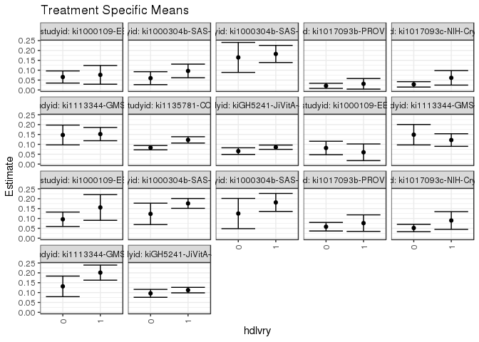

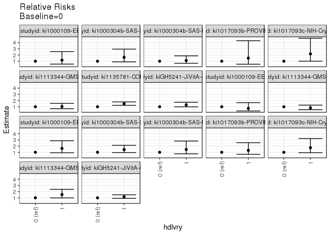

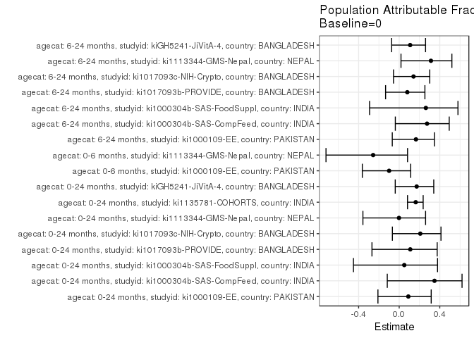

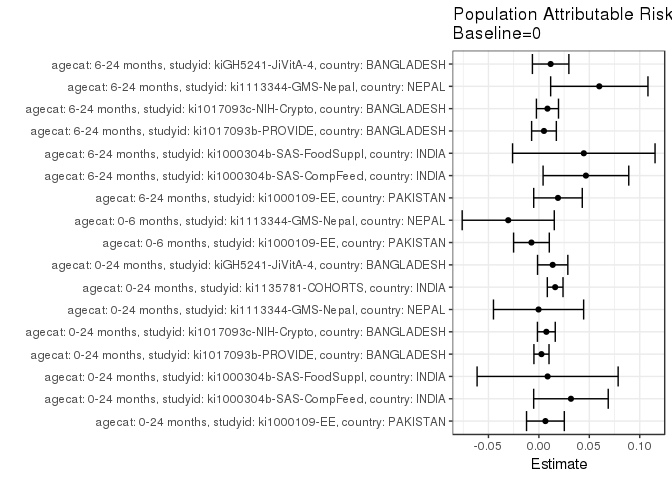

## Results Table

### Parameter: TSM

| agecat | studyid | country | intervention_level | baseline_level | estimate | ci_lower | ci_upper |
| --- | --- | --- | --- | --- | --- | --- | --- |
| 0-24 months | ki1000109-EE | PAKISTAN | 0 | NA | 0.0655146 | 0.0348357 | 0.0961935 |
| 0-24 months | ki1000109-EE | PAKISTAN | 1 | NA | 0.0765118 | 0.0290144 | 0.1240093 |
| 0-24 months | ki1000304b-SAS-CompFeed | INDIA | 0 | NA | 0.0596026 | 0.0268592 | 0.0923461 |
| 0-24 months | ki1000304b-SAS-CompFeed | INDIA | 1 | NA | 0.0963731 | 0.0619791 | 0.1307670 |
| 0-24 months | ki1000304b-SAS-FoodSuppl | INDIA | 0 | NA | 0.1646757 | 0.0887800 | 0.2405713 |
| 0-24 months | ki1000304b-SAS-FoodSuppl | INDIA | 1 | NA | 0.1823405 | 0.1389752 | 0.2257057 |
| 0-24 months | ki1017093b-PROVIDE | BANGLADESH | 0 | NA | 0.0208768 | 0.0080632 | 0.0336904 |
| 0-24 months | ki1017093b-PROVIDE | BANGLADESH | 1 | NA | 0.0310559 | 0.0042398 | 0.0578720 |
| 0-24 months | ki1017093c-NIH-Crypto | BANGLADESH | 0 | NA | 0.0282167 | 0.0145770 | 0.0418565 |
| 0-24 months | ki1017093c-NIH-Crypto | BANGLADESH | 1 | NA | 0.0613616 | 0.0245289 | 0.0981943 |
| 0-24 months | ki1113344-GMS-Nepal | NEPAL | 0 | NA | 0.1473356 | 0.0971962 | 0.1974749 |
| 0-24 months | ki1113344-GMS-Nepal | NEPAL | 1 | NA | 0.1518514 | 0.1182347 | 0.1854681 |
| 0-24 months | ki1135781-COHORTS | INDIA | 0 | NA | 0.0830694 | 0.0721617 | 0.0939770 |
| 0-24 months | ki1135781-COHORTS | INDIA | 1 | NA | 0.1224584 | 0.1064339 | 0.1384830 |
| 0-24 months | kiGH5241-JiVitA-4 | BANGLADESH | 0 | NA | 0.0657012 | 0.0488892 | 0.0825132 |
| 0-24 months | kiGH5241-JiVitA-4 | BANGLADESH | 1 | NA | 0.0854196 | 0.0745241 | 0.0963152 |
| 0-6 months | ki1000109-EE | PAKISTAN | 0 | NA | 0.0815543 | 0.0474381 | 0.1156705 |
| 0-6 months | ki1000109-EE | PAKISTAN | 1 | NA | 0.0597450 | 0.0176172 | 0.1018729 |
| 0-6 months | ki1113344-GMS-Nepal | NEPAL | 0 | NA | 0.1487396 | 0.0970272 | 0.2004519 |
| 0-6 months | ki1113344-GMS-Nepal | NEPAL | 1 | NA | 0.1218216 | 0.0899333 | 0.1537098 |
| 6-24 months | ki1000109-EE | PAKISTAN | 0 | NA | 0.0958126 | 0.0592374 | 0.1323877 |
| 6-24 months | ki1000109-EE | PAKISTAN | 1 | NA | 0.1558346 | 0.0906861 | 0.2209831 |
| 6-24 months | ki1000304b-SAS-CompFeed | INDIA | 0 | NA | 0.1232339 | 0.0691534 | 0.1773143 |
| 6-24 months | ki1000304b-SAS-CompFeed | INDIA | 1 | NA | 0.1761292 | 0.1511599 | 0.2010984 |
| 6-24 months | ki1000304b-SAS-FoodSuppl | INDIA | 0 | NA | 0.1250000 | 0.0484992 | 0.2015008 |
| 6-24 months | ki1000304b-SAS-FoodSuppl | INDIA | 1 | NA | 0.1811594 | 0.1356555 | 0.2266633 |
| 6-24 months | ki1017093b-PROVIDE | BANGLADESH | 0 | NA | 0.0581819 | 0.0365167 | 0.0798472 |
| 6-24 months | ki1017093b-PROVIDE | BANGLADESH | 1 | NA | 0.0763592 | 0.0345384 | 0.1181799 |
| 6-24 months | ki1017093c-NIH-Crypto | BANGLADESH | 0 | NA | 0.0517545 | 0.0330734 | 0.0704356 |
| 6-24 months | ki1017093c-NIH-Crypto | BANGLADESH | 1 | NA | 0.0897525 | 0.0448735 | 0.1346314 |
| 6-24 months | ki1113344-GMS-Nepal | NEPAL | 0 | NA | 0.1315465 | 0.0794315 | 0.1836615 |
| 6-24 months | ki1113344-GMS-Nepal | NEPAL | 1 | NA | 0.2010898 | 0.1628127 | 0.2393669 |
| 6-24 months | kiGH5241-JiVitA-4 | BANGLADESH | 0 | NA | 0.0961320 | 0.0761309 | 0.1161332 |
| 6-24 months | kiGH5241-JiVitA-4 | BANGLADESH | 1 | NA | 0.1126451 | 0.0987459 | 0.1265444 |

### Parameter: E(Y)

| agecat | studyid | country | intervention_level | baseline_level | estimate | ci_lower | ci_upper |
| --- | --- | --- | --- | --- | --- | --- | --- |
| 0-24 months | ki1000109-EE | PAKISTAN | NA | NA | 0.0720000 | 0.0458029 | 0.0981971 |
| 0-24 months | ki1000304b-SAS-CompFeed | INDIA | NA | NA | 0.0913978 | 0.0593363 | 0.1234594 |
| 0-24 months | ki1000304b-SAS-FoodSuppl | INDIA | NA | NA | 0.1733333 | 0.1349698 | 0.2116969 |
| 0-24 months | ki1017093b-PROVIDE | BANGLADESH | NA | NA | 0.0234375 | 0.0117074 | 0.0351676 |
| 0-24 months | ki1017093c-NIH-Crypto | BANGLADESH | NA | NA | 0.0356164 | 0.0221630 | 0.0490699 |
| 0-24 months | ki1113344-GMS-Nepal | NEPAL | NA | NA | 0.1470054 | 0.1174112 | 0.1765996 |
| 0-24 months | ki1135781-COHORTS | INDIA | NA | NA | 0.0992114 | 0.0898650 | 0.1085578 |
| 0-24 months | kiGH5241-JiVitA-4 | BANGLADESH | NA | NA | 0.0793848 | 0.0702123 | 0.0885573 |
| 0-6 months | ki1000109-EE | PAKISTAN | NA | NA | 0.0741758 | 0.0472177 | 0.1011340 |
| 0-6 months | ki1113344-GMS-Nepal | NEPAL | NA | NA | 0.1183432 | 0.0901986 | 0.1464877 |
| 6-24 months | ki1000109-EE | PAKISTAN | NA | NA | 0.1147541 | 0.0820564 | 0.1474518 |
| 6-24 months | ki1000304b-SAS-CompFeed | INDIA | NA | NA | 0.1698686 | 0.1413755 | 0.1983616 |
| 6-24 months | ki1000304b-SAS-FoodSuppl | INDIA | NA | NA | 0.1695402 | 0.1300601 | 0.2090204 |
| 6-24 months | ki1017093b-PROVIDE | BANGLADESH | NA | NA | 0.0632280 | 0.0437545 | 0.0827015 |
| 6-24 months | ki1017093c-NIH-Crypto | BANGLADESH | NA | NA | 0.0602582 | 0.0425793 | 0.0779372 |
| 6-24 months | ki1113344-GMS-Nepal | NEPAL | NA | NA | 0.1914498 | 0.1581730 | 0.2247266 |
| 6-24 months | kiGH5241-JiVitA-4 | BANGLADESH | NA | NA | 0.1077887 | 0.0960896 | 0.1194877 |

### Parameter: RR

| agecat | studyid | country | intervention_level | baseline_level | estimate | ci_lower | ci_upper |
| --- | --- | --- | --- | --- | --- | --- | --- |
| 0-24 months | ki1000109-EE | PAKISTAN | 0 | 0 | 1.0000000 | 1.0000000 | 1.000000 |
| 0-24 months | ki1000109-EE | PAKISTAN | 1 | 0 | 1.1678593 | 0.5366159 | 2.541660 |
| 0-24 months | ki1000304b-SAS-CompFeed | INDIA | 0 | 0 | 1.0000000 | 1.0000000 | 1.000000 |
| 0-24 months | ki1000304b-SAS-CompFeed | INDIA | 1 | 0 | 1.6169257 | 0.8882404 | 2.943402 |
| 0-24 months | ki1000304b-SAS-FoodSuppl | INDIA | 0 | 0 | 1.0000000 | 1.0000000 | 1.000000 |
| 0-24 months | ki1000304b-SAS-FoodSuppl | INDIA | 1 | 0 | 1.1072703 | 0.6606233 | 1.855895 |
| 0-24 months | ki1017093b-PROVIDE | BANGLADESH | 0 | 0 | 1.0000000 | 1.0000000 | 1.000000 |
| 0-24 months | ki1017093b-PROVIDE | BANGLADESH | 1 | 0 | 1.4875776 | 0.5156933 | 4.291091 |
| 0-24 months | ki1017093c-NIH-Crypto | BANGLADESH | 0 | 0 | 1.0000000 | 1.0000000 | 1.000000 |
| 0-24 months | ki1017093c-NIH-Crypto | BANGLADESH | 1 | 0 | 2.1746514 | 1.0062995 | 4.699504 |
| 0-24 months | ki1113344-GMS-Nepal | NEPAL | 0 | 0 | 1.0000000 | 1.0000000 | 1.000000 |
| 0-24 months | ki1113344-GMS-Nepal | NEPAL | 1 | 0 | 1.0306499 | 0.6867889 | 1.546675 |
| 0-24 months | ki1135781-COHORTS | INDIA | 0 | 0 | 1.0000000 | 1.0000000 | 1.000000 |
| 0-24 months | ki1135781-COHORTS | INDIA | 1 | 0 | 1.4741708 | 1.2252863 | 1.773610 |
| 0-24 months | kiGH5241-JiVitA-4 | BANGLADESH | 0 | 0 | 1.0000000 | 1.0000000 | 1.000000 |
| 0-24 months | kiGH5241-JiVitA-4 | BANGLADESH | 1 | 0 | 1.3001238 | 0.9778428 | 1.728624 |
| 0-6 months | ki1000109-EE | PAKISTAN | 0 | 0 | 1.0000000 | 1.0000000 | 1.000000 |
| 0-6 months | ki1000109-EE | PAKISTAN | 1 | 0 | 0.7325799 | 0.3229173 | 1.661953 |
| 0-6 months | ki1113344-GMS-Nepal | NEPAL | 0 | 0 | 1.0000000 | 1.0000000 | 1.000000 |
| 0-6 months | ki1113344-GMS-Nepal | NEPAL | 1 | 0 | 0.8190258 | 0.5299261 | 1.265843 |
| 6-24 months | ki1000109-EE | PAKISTAN | 0 | 0 | 1.0000000 | 1.0000000 | 1.000000 |
| 6-24 months | ki1000109-EE | PAKISTAN | 1 | 0 | 1.6264523 | 0.9244639 | 2.861493 |
| 6-24 months | ki1000304b-SAS-CompFeed | INDIA | 0 | 0 | 1.0000000 | 1.0000000 | 1.000000 |
| 6-24 months | ki1000304b-SAS-CompFeed | INDIA | 1 | 0 | 1.4292266 | 0.9569573 | 2.134566 |
| 6-24 months | ki1000304b-SAS-FoodSuppl | INDIA | 0 | 0 | 1.0000000 | 1.0000000 | 1.000000 |
| 6-24 months | ki1000304b-SAS-FoodSuppl | INDIA | 1 | 0 | 1.4492754 | 0.7479025 | 2.808386 |
| 6-24 months | ki1017093b-PROVIDE | BANGLADESH | 0 | 0 | 1.0000000 | 1.0000000 | 1.000000 |
| 6-24 months | ki1017093b-PROVIDE | BANGLADESH | 1 | 0 | 1.3124209 | 0.6763673 | 2.546617 |
| 6-24 months | ki1017093c-NIH-Crypto | BANGLADESH | 0 | 0 | 1.0000000 | 1.0000000 | 1.000000 |
| 6-24 months | ki1017093c-NIH-Crypto | BANGLADESH | 1 | 0 | 1.7341973 | 0.9359946 | 3.213096 |
| 6-24 months | ki1113344-GMS-Nepal | NEPAL | 0 | 0 | 1.0000000 | 1.0000000 | 1.000000 |
| 6-24 months | ki1113344-GMS-Nepal | NEPAL | 1 | 0 | 1.5286595 | 0.9848864 | 2.372659 |
| 6-24 months | kiGH5241-JiVitA-4 | BANGLADESH | 0 | 0 | 1.0000000 | 1.0000000 | 1.000000 |
| 6-24 months | kiGH5241-JiVitA-4 | BANGLADESH | 1 | 0 | 1.1717752 | 0.9209958 | 1.490840 |

### Parameter: PAR

| agecat | studyid | country | intervention_level | baseline_level | estimate | ci_lower | ci_upper |
| --- | --- | --- | --- | --- | --- | --- | --- |
| 0-24 months | ki1000109-EE | PAKISTAN | 0 | NA | 0.0064854 | -0.0122454 | 0.0252161 |
| 0-24 months | ki1000304b-SAS-CompFeed | INDIA | 0 | NA | 0.0317952 | -0.0051651 | 0.0687555 |
| 0-24 months | ki1000304b-SAS-FoodSuppl | INDIA | 0 | NA | 0.0086577 | -0.0612650 | 0.0785804 |
| 0-24 months | ki1017093b-PROVIDE | BANGLADESH | 0 | NA | 0.0025607 | -0.0049237 | 0.0100450 |
| 0-24 months | ki1017093c-NIH-Crypto | BANGLADESH | 0 | NA | 0.0073997 | -0.0014301 | 0.0162295 |
| 0-24 months | ki1113344-GMS-Nepal | NEPAL | 0 | NA | -0.0003301 | -0.0450303 | 0.0443700 |
| 0-24 months | ki1135781-COHORTS | INDIA | 0 | NA | 0.0161420 | 0.0083565 | 0.0239276 |
| 0-24 months | kiGH5241-JiVitA-4 | BANGLADESH | 0 | NA | 0.0136837 | -0.0013291 | 0.0286964 |
| 0-6 months | ki1000109-EE | PAKISTAN | 0 | NA | -0.0073785 | -0.0250829 | 0.0103260 |
| 0-6 months | ki1113344-GMS-Nepal | NEPAL | 0 | NA | -0.0303964 | -0.0760547 | 0.0152620 |
| 6-24 months | ki1000109-EE | PAKISTAN | 0 | NA | 0.0189415 | -0.0051337 | 0.0430167 |
| 6-24 months | ki1000304b-SAS-CompFeed | INDIA | 0 | NA | 0.0466347 | 0.0041611 | 0.0891083 |
| 6-24 months | ki1000304b-SAS-FoodSuppl | INDIA | 0 | NA | 0.0445402 | -0.0260953 | 0.1151758 |
| 6-24 months | ki1017093b-PROVIDE | BANGLADESH | 0 | NA | 0.0050460 | -0.0072156 | 0.0173077 |
| 6-24 months | ki1017093c-NIH-Crypto | BANGLADESH | 0 | NA | 0.0085038 | -0.0024399 | 0.0194475 |
| 6-24 months | ki1113344-GMS-Nepal | NEPAL | 0 | NA | 0.0599033 | 0.0116683 | 0.1081384 |
| 6-24 months | kiGH5241-JiVitA-4 | BANGLADESH | 0 | NA | 0.0116566 | -0.0064142 | 0.0297275 |

### Parameter: PAF

| agecat | studyid | country | intervention_level | baseline_level | estimate | ci_lower | ci_upper |
| --- | --- | --- | --- | --- | --- | --- | --- |
| 0-24 months | ki1000109-EE | PAKISTAN | 0 | NA | 0.0900749 | -0.2095568 | 0.3154818 |
| 0-24 months | ki1000304b-SAS-CompFeed | INDIA | 0 | NA | 0.3478769 | -0.1175046 | 0.6194516 |
| 0-24 months | ki1000304b-SAS-FoodSuppl | INDIA | 0 | NA | 0.0499481 | -0.4509589 | 0.3779296 |
| 0-24 months | ki1017093b-PROVIDE | BANGLADESH | 0 | NA | 0.1092554 | -0.2683734 | 0.3744540 |
| 0-24 months | ki1017093c-NIH-Crypto | BANGLADESH | 0 | NA | 0.2077605 | -0.0671031 | 0.4118250 |
| 0-24 months | ki1113344-GMS-Nepal | NEPAL | 0 | NA | -0.0022456 | -0.3575681 | 0.2600767 |
| 0-24 months | ki1135781-COHORTS | INDIA | 0 | NA | 0.1627035 | 0.0821598 | 0.2361793 |
| 0-24 months | kiGH5241-JiVitA-4 | BANGLADESH | 0 | NA | 0.1723712 | -0.0389660 | 0.3407202 |
| 0-6 months | ki1000109-EE | PAKISTAN | 0 | NA | -0.0994725 | -0.3636157 | 0.1135040 |
| 0-6 months | ki1113344-GMS-Nepal | NEPAL | 0 | NA | -0.2568494 | -0.7214416 | 0.0823561 |
| 6-24 months | ki1000109-EE | PAKISTAN | 0 | NA | 0.1650618 | -0.0682433 | 0.3474128 |
| 6-24 months | ki1000304b-SAS-CompFeed | INDIA | 0 | NA | 0.2745338 | -0.0380986 | 0.4930142 |
| 6-24 months | ki1000304b-SAS-FoodSuppl | INDIA | 0 | NA | 0.2627119 | -0.2917963 | 0.5791954 |
| 6-24 months | ki1017093b-PROVIDE | BANGLADESH | 0 | NA | 0.0798071 | -0.1341626 | 0.2534095 |
| 6-24 months | ki1017093c-NIH-Crypto | BANGLADESH | 0 | NA | 0.1411222 | -0.0558875 | 0.3013735 |
| 6-24 months | ki1113344-GMS-Nepal | NEPAL | 0 | NA | 0.3128931 | 0.0177074 | 0.5193735 |
| 6-24 months | kiGH5241-JiVitA-4 | BANGLADESH | 0 | NA | 0.1081434 | -0.0746673 | 0.2598563 |